# PCA on graph and multigraph

In this document, we try would try to cluster graph node using a particular PCA on graph, and maybe extend the notion to to cluster node with several graph data.

# Test on simulation for one graph

In this section, we would like to try the method found in (Saerens et al. 2004) using principal component analysis on a weighted graph.

Let $V = \{1, \dots, d\}$ the set of nodes.

## Method

The procedure use the Laplacian matrix of a weighted graph. Let $\mathcal G = (V, E, W)$ an undirected weigthed graph, where $W$ is the weught matrix where $w_{ij} \ge 0$. From this matrix and the set of edges $E$, we define the adjacency matrix $A$ as:

$$a_{ij} = \begin{cases} w_{ij} \quad \text{if } (i,j) \in E, \\ 0 \quad
(i,j) \notin E, \end{cases}$$

From this matrix, we are able to define the Laplacian matrix $L=D-A$ where the matrix $D$ is a diagonal matrix where $d_i = \sum_{i=1}^d a_{ij}$.

The goal is to use the generalised inverse of the Laplacian matrix $L^+$ as a new metric called the Euclidian Commute Time Distance (ECTD), and make PCA on this matrix, see (Saerens et al. 2004) for details. It is also linked to the spectral clustering to the graph.

## Adaptation for extremal graphical model

In their example, they used the inverse of the distance between the nodes to set the weights.

The graphical models for extreme produce a graph where an edge does not exist between two nodes if they are independent conditionally to the other nodes. In that sense, we can use weights that measure the strength of extremal dependence between them and mix it with a graph estimation of the vector to being the clustering.

In (Engelke and Volgushev 2022), they see the graph weighted by two notion : the variogram or the extremal coefficient. Tey compute a minimal spanning tree to compute their estimation which are consistent for empirical estimation of these two quantities.

Thus, we will use two possible weights:

$$w_{ij} = \chi_{ij} \quad \quad \text{or} \quad \quad w_{ij} =
\frac{1}{\Gamma_{ij}}$$

## Application in simulation

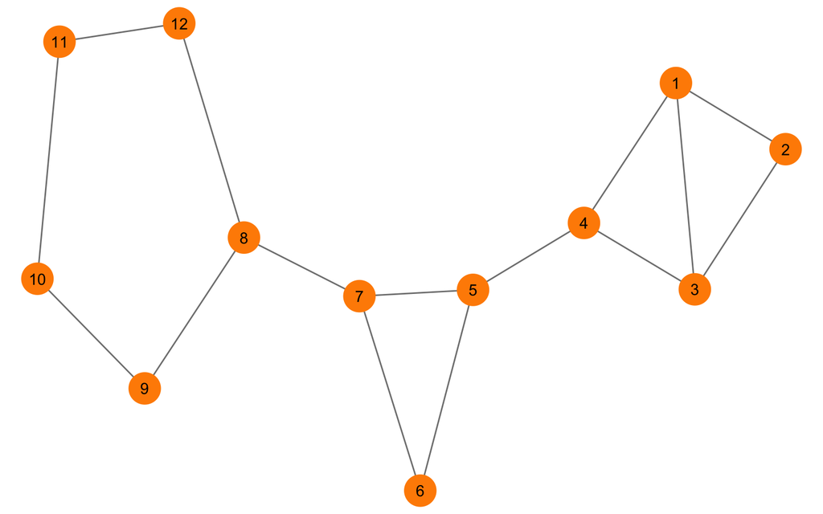

Graphical structure of the simulation.

A first look on this graph suggests us to make the 3 clusters formed by $\{1,2,3,4\}$, $\{5,6,7\}$ and $\{8,9,10,11,12\}$. What clustering will we produce with the procedure ?

### Known graph

First, let’s see what is going on when we know the graph structure. We assume that the data are Husler-Reiss Pareto distributed, and we take a random variogram with the respect to this graphical structure thanks to `generate_random_graphical_Gamma` function from `graphicalExtremes` package. We get:

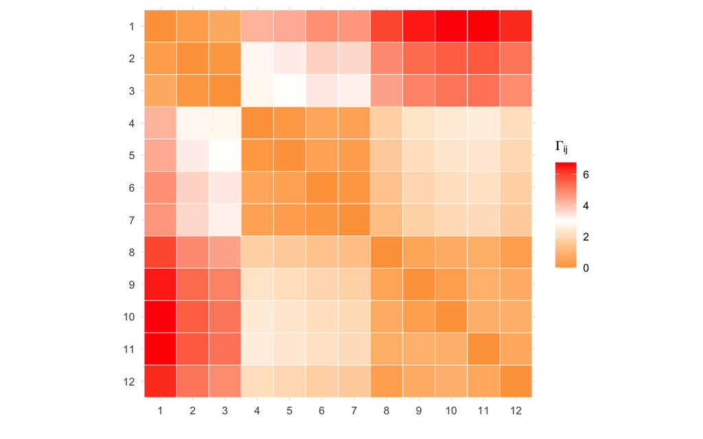

Variogram matrix.

And the extremal coefficient matrix:

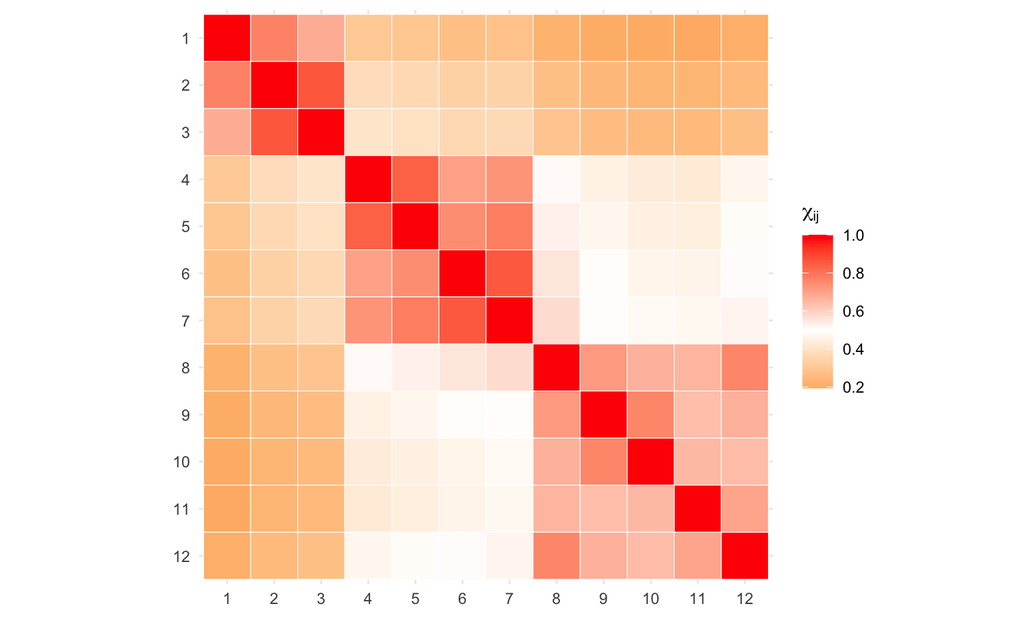

Extremal coefficient matrix.

We can stress that block structure of the matrix seems to gather the node 4 with the second group instead of the first one with only the graphical structure. This observation will be confirmed with the method.

Indeed, if we compute the PCA on the graph with the corresponding Laplacian matrix we get this for the two firsts principal component for the variogram:

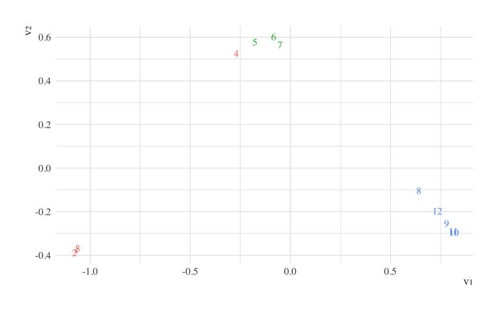

First principal plane with the variogram Laplacian with known graph.

and this for the extremal coefficient:

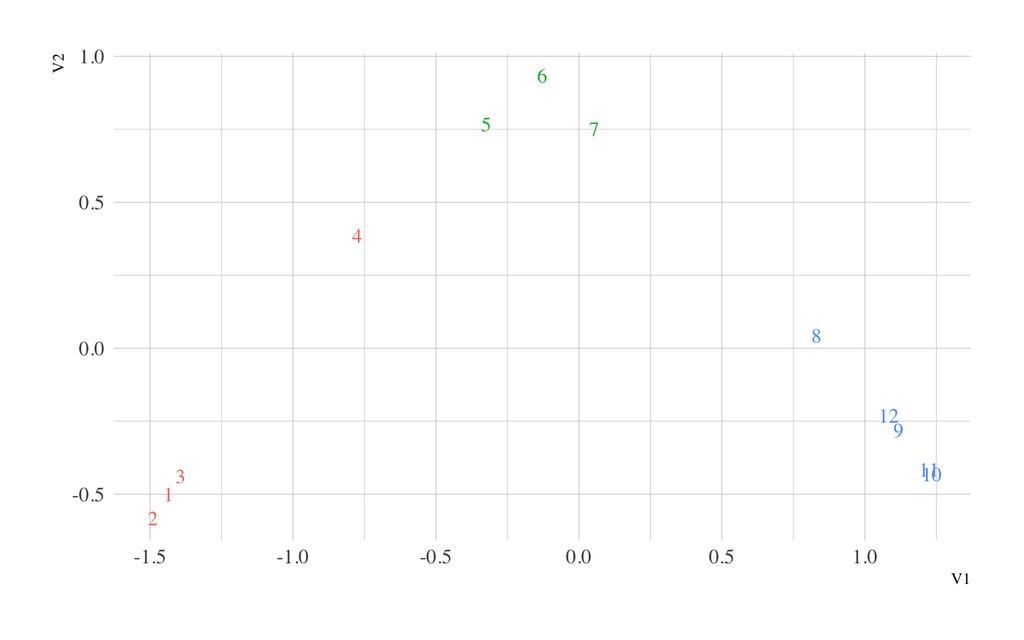

First principal plane with the extremal coefficient Laplacian with known graph.

The colors are made of the initial guess for the clusters. Here, even knowing the true structure, we observe an uncertainty for the node 4, a doubt hightlighted with the extremal coefficient Laplacian.

### Unknown graph

With the unknown graph, we need first to estimate the graphical structure. In order to do that, we use `eglearn` function from `graphicalExtremes` introduced in (Engelke, Lalancette, and Volgushev 2024). We get the following graph for a first estimation:

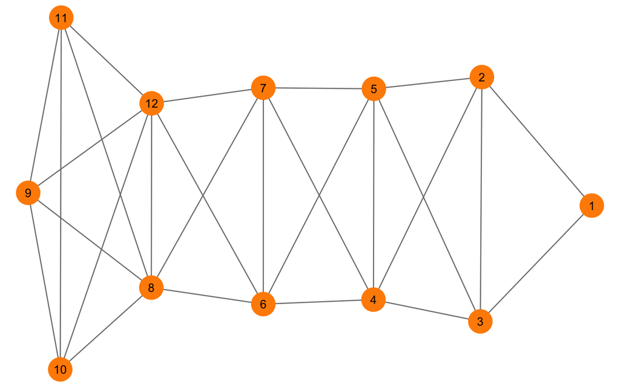

Estimation of the graph.

We do not have the right structure here, it can change the results from the previous estimation, and it could erase the encertainty seen for the node 4.

Thus, we get with this graphical structure the following results for the variogram :

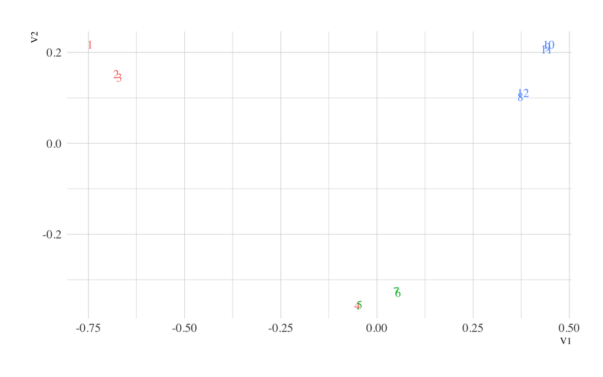

and for the extremal coefficient:

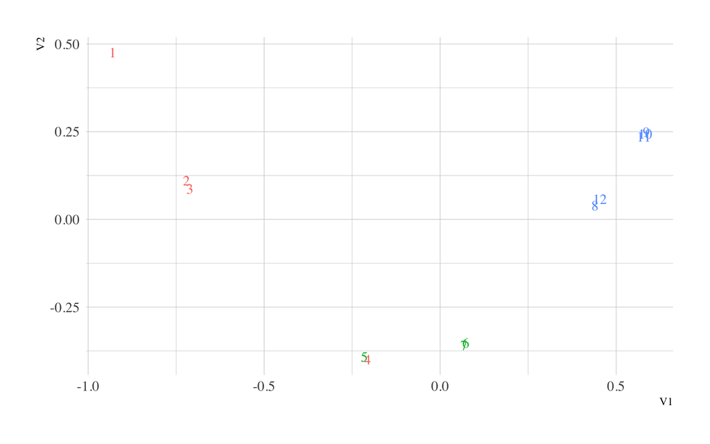

First principal plane with the extremal coefficient Laplacian with unknown graph.

As expected, the node 4 is totally associated with the second group. With this first simulation, we can say that the procedure is sensible to the coefficient of the weights, not only on the graphical structure, a conclusion that we could predict.

### Simulation with all same dependence

We would like to see if the algorithm can separate the nodes even with no clear block matrix structure in the variogram and the extremal coefficient matrix.

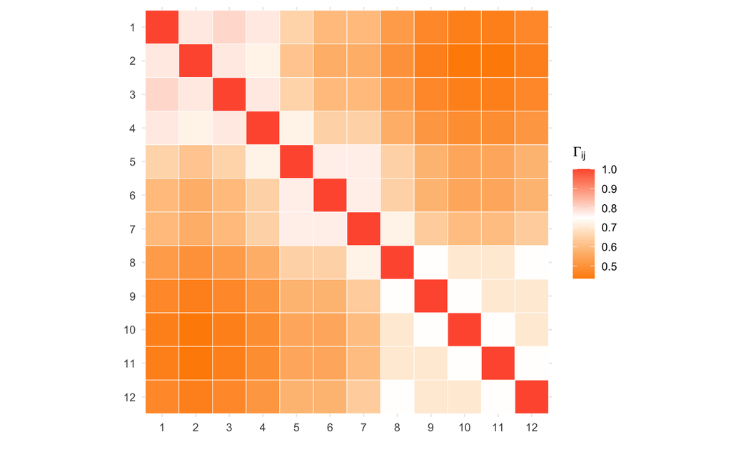

The goal is to see if we can see the clustering as an indicator of density of edges between the nodes in the same cluster.

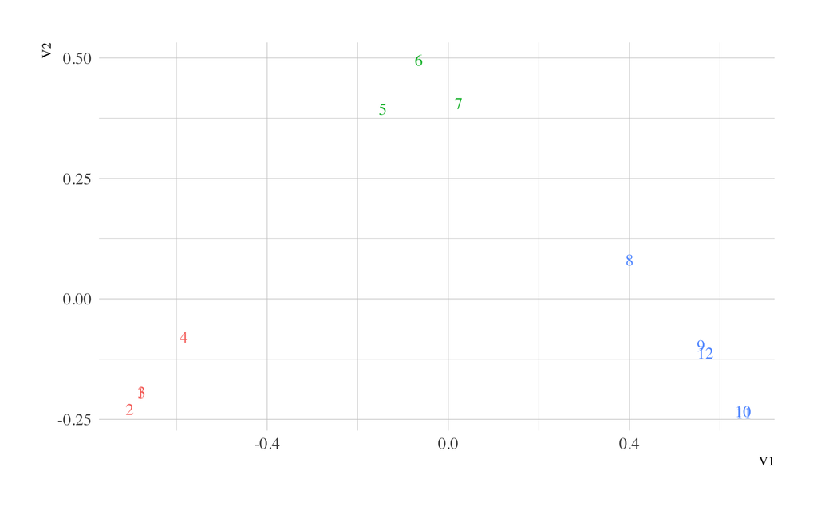

First principal plane with the extremal coefficient Laplacian with known same coefficient graph.